# MODELOS PREDICTIVOS BASADOS EN ARBOLES DE DECISIÓN

## Comprobación de que nuestro entorno ejecuta con GPU

```python
import pandas as pd
import numpy as np
import matplotlib.pyplot as plt
import os
os.environ['TF_CPP_MIN_LOG_LEVEL'] = '2'  # 0 = all, 1 = INFO, 2 = WARNING, 3 = ERROR

from sklearn.model_selection import train_test_split, GridSearchCV, cross_val_score, KFold
from sklearn.ensemble import RandomForestRegressor, GradientBoostingRegressor
from sklearn.metrics import mean_squared_error, mean_absolute_error, r2_score, median_absolute_error
from hyperopt import hp, STATUS_OK, fmin, tpe, Trials, space_eval
from functools import partial
import xgboost as xgb
import lightgbm as lgb
from joblib import dump, load
import tensorflow as tf

from tqdm import tqdm
import time
import warnings
warnings.filterwarnings('ignore')

# Obtenemos la lista de dispositivos utilizables
visible_devices = tf.config.experimental.list_physical_devices()

if len(visible_devices) == 0:
    print("No se detectaron dispositivos físicos (GPU/TPU).")
else:
    for device in visible_devices:
        print(f"Dispositivo detectado: {device.name}")
```

```
Dispositivo detectado: /physical_device:CPU:0
Dispositivo detectado: /physical_device:GPU:0
```

```python
df = pd.read_csv(f"./DatosViviendas.csv")
print('Tamaño dataframe: ', df.shape)
print('\nFormato de las variables: \n', df.dtypes)
```

```
Tamaño dataframe:  (51585, 16)

Formato de las variables:
 Año                  int64
Mes                  int64
Dia                  int64
Caracteristicas      int64
Habitaciones         int64
Aseos                int64
Terraza              int64
Piscina              int64
Garaje               int64
CUDIS                int64
Latitud            float64
Longitud           float64
Metros             float64
PCA1               float64
PCA2               float64
Precio             float64
dtype: object
```

```python
# Dividimos el dataset en variables características (X) y objetivo (y)
X = df.drop('Precio', axis=1)
y = df['Precio']

# Dividimos los datos en conjuntos de entrenamiento y prueba
X_train, X_test, y_train, y_test = train_test_split(X, y, test_size=0.2, random_state=42)
```

# Random Forest

Es un método de ensamblaje que utiliza múltiples árboles de decisión para mejorar la robustez y reducir el riesgo de sobreajuste. Es bueno para manejar una gran cantidad de características y es generalmente resistente a los valores atípicos.

```python
# Creamos el modelo de Random Forest
rf = RandomForestRegressor(n_estimators=2000, random_state=42)

# Entrenamos el modelo
start_time = time.time()
rf.fit(X_train, y_train)
end_time = time.time()
rf_time = end_time - start_time

print(f'Tiempo de entrenamiento: {rf_time}')
```

```
Tiempo de entrenamiento: 296.7242703437805
```

Para realizar un análisis detallado de los resultados obtenidos por los modelos que desarrollemos, utilizaremos las siguientes métricas:

```
- Tiempo de entrenamiento
- MSE (Mean Squared Error)
- RMSE (Root Mean Squared Error)
- MAE (Mean Absolute Error)
- Complementario de R² (1 - R²).
```

También se tendrán en cuenta las características específicas del conjunto de datos para entender mejor el rendimiento de cada modelo.

```python
def evaluacion(model, X_test, y_test):
    metricas = {}
    # Predecimos los valores de 'Precio' para el conjunto de prueba
    y_pred = model.predict(X_test)

    # MSE - Error Cuadrático Medio
    metricas['MSE'] = mean_squared_error(y_test, y_pred)

    # RMSE - Raíz del Error Cuadrático Medio
    metricas['RMSE'] = np.sqrt(metricas['MSE'])

    # MAE - Error Absoluto Medio
    metricas['MAE'] = mean_absolute_error(y_test, y_pred)

    # MedAE - Mediana del Error Absoluto
    metricas['MedAE'] = median_absolute_error(y_test, y_pred)

    # Coeficiente de Determinación, R²
    metricas['R2'] = r2_score(y_test, y_pred)

    # Imprimir resultados
    print("MSE:", metricas['MSE'])
    print("RMSE:", metricas['RMSE'])
    print("MAE:", metricas['MAE'])
    print("MedAE:", metricas['MedAE'])
    print("R²:", metricas['R2'])

    return metricas
```

```python
rf_metrics = evaluacion(rf, X_test, y_test)
rf_metrics['Tiempo de entrenamiento'] = rf_time
```

[output not shown]

# Gradient Boosting

Construye árboles secuencialmente, donde cada árbol intenta corregir los errores del árbol anterior. Es eficaz y preciso, pero puede ser susceptible al sobreajuste si no se configura cuidadosamente.

```python
# Creamos el modelo GradientBoostingRegressor
gbm_model = GradientBoostingRegressor(n_estimators=4000, random_state=42)

# Entrenamos el modelo
start_time = time.time()
gbm_model.fit(X_train, y_train)
end_time = time.time()
gbm_time = end_time - start_time

print(f'Tiempo de entrenamiento: {gbm_time}')
```

```
Tiempo de entrenamiento: 179.91209077835083
```

```python
gbm_metrics = evaluacion(gbm_model, X_test, y_test)
gbm_metrics['Tiempo de entrenamiento'] = gbm_time
```

[output not shown]

# Extreme Gradient Boosting (XGBoost)

Una implementación optimizada de Gradient Boosting. Es conocido por su eficiencia en velocidad y rendimiento, y es ampliamente utilizado en competiciones de ciencia de datos.

```python
# Creamos el modelo XGBRegressor
xg_model = xgb.XGBRegressor(n_estimators=10000, tree_method='gpu_hist', random_state=42)

# Entrenamos el modelo
start_time = time.time()
xg_model.fit(X_train, y_train)
end_time = time.time()
xg_time = end_time - start_time

print(f'Tiempo de entrenamiento: {xg_time}')
```

```
Tiempo de entrenamiento: 53.527199506759644
```

```python
xg_metrics = evaluacion(xg_model, X_test, y_test)
xg_metrics['Tiempo de entrenamiento'] = xg_time
```

[output not shown]

# Light Gradient Boosting Method (LightGBM)

Similar a XGBoost, pero generalmente más rápido y eficiente, especialmente en conjuntos de datos grandes. Utiliza un método de crecimiento de árboles basado en gradientes que puede ser más eficiente en términos de memoria y tiempo de computación.

```python
# Creamos el modelo LGBMRegressor
lgbm_model = lgb.LGBMRegressor(n_estimators=10000, random_state=42)

# Entrenamos el modelo
start_time = time.time()
lgbm_model.fit(X_train, y_train)
end_time = time.time()
lgbm_time = end_time - start_time

print(f'Tiempo de entrenamiento: {lgbm_time}')
```

```
[LightGBM] [Info] Auto-choosing row-wise multi-threading, the overhead of testing was 0.002021 seconds.
You can set `force_row_wise=true` to remove the overhead.
And if memory is not enough, you can set `force_col_wise=true`.
[LightGBM] [Info] Total Bins 1081
[LightGBM] [Info] Number of data points in the train set: 41268, number of used features: 15
[LightGBM] [Info] Start training from score 381908.719274
Tiempo de entrenamiento: 43.73165559768677
```

```python
lgbm_metrics = evaluacion(lgbm_model, X_test, y_test)
lgbm_metrics['Tiempo de entrenamiento'] = lgbm_time
```

[output not shown]

```python
def comparar_metricas(modelos_metricas, nombres_modelos):
    metricas = ['MSE', 'RMSE', 'MAE', 'MedAE', 'R2', 'MAPE', 'Tiempo de entrenamiento']

    data = {metrica: [modelo[metrica] for modelo in modelos_metricas] for metrica in metricas}
    df = pd.DataFrame(data, index=nombres_modelos)

    # Iteramos sobre cada métrica y crear una gráfica de barras
    for metrica in metricas:
        # Obtenemos los valores para la métrica actual de cada modelo
        valores = [modelo[metrica] for modelo in modelos_metricas]

        # Creamos la gráfica de barras
        plt.figure(figsize=(10, 6))
        plt.bar(nombres_modelos, valores, color=['blue', 'green', 'red', 'purple'])
        plt.title(f'Comparación de {metrica}')
        plt.ylabel(metrica)
        plt.xlabel('Modelos')
        for i, v in enumerate(valores):
            plt.text(i, v + max(valores)*0.01, f"{v:.2f}", ha='center')
        plt.show()

    return df
```

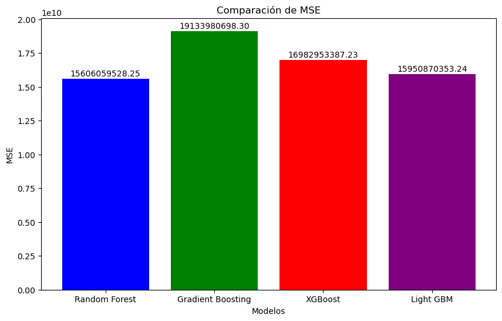

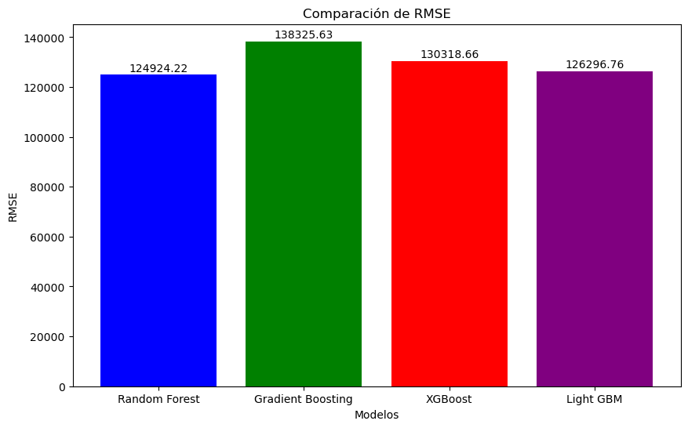

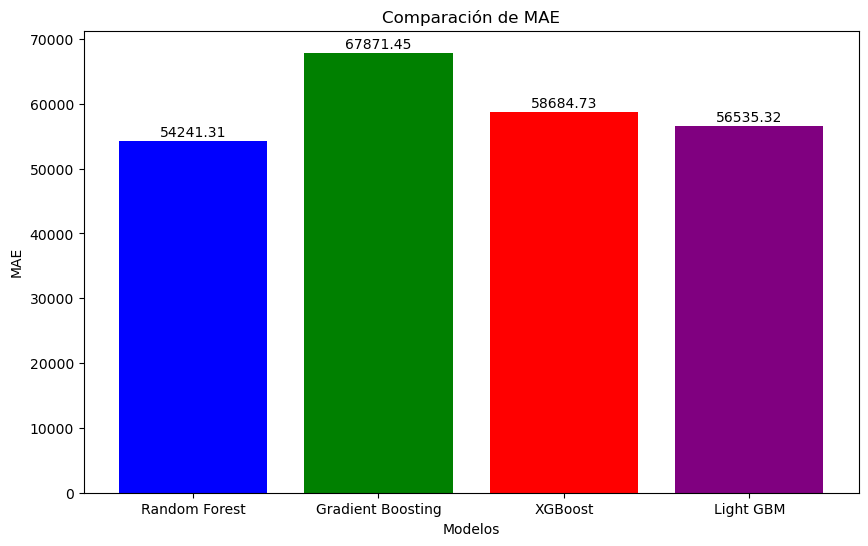

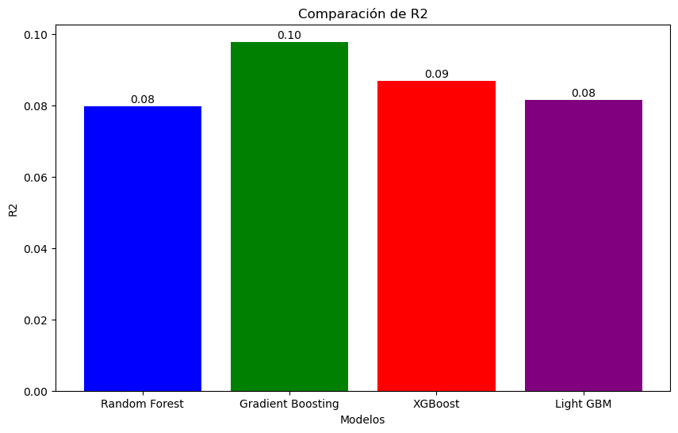

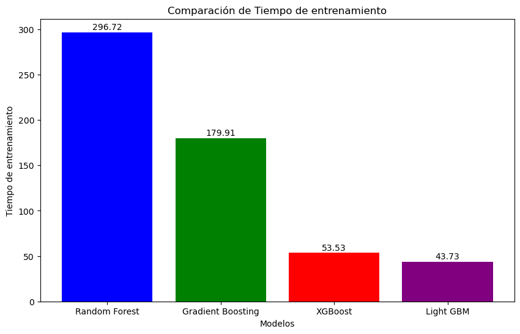

|  | MSE | RMSE | MAE | R2 | Tiempo de entrenamiento |
| --- | --- | --- | --- | --- | --- |
| Random Forest | 1.560606e+10 | 124924.215140 | 54241.310005 | 0.079756 | 296.724270 |
| Gradient Boosting | 1.913398e+10 | 138325.632832 | 67871.448534 | 0.097786 | 179.912091 |
| XGBoost | 1.698295e+10 | 130318.660932 | 58684.733286 | 0.086793 | 53.527200 |
| Light GBM | 1.595087e+10 | 126296.755118 | 56535.319443 | 0.081519 | 43.731656 |

```python
comparar_metricas([rf_metrics, gbm_metrics, xg_metrics, lgbm_metrics], ['Random Forest', 'Gradient Boosting', 'XGBoost', 'Light GBM'])
```